# Server facing rvest tutorial

# Introduction

Server (back-end) facing data is data that is stored on a server, usually in a nice clean data base. You can usually tell when a data set is server facing because the data either takes time to load or the data changes while you are browsing (think weather forecasts updating)

## The problem

We are going to extract the weather forecast for a city of interest. The tutorial will show you how to find the location of the server’s API that contains the data.

## The website

Navigate to http://theweathernetwork.com and you will see the following

[figure not shown]

Specifically you can see a list of cities that we may want to extract forecasts for

[figure not shown]

Now we could proceed as before and right click to inspect any element as before

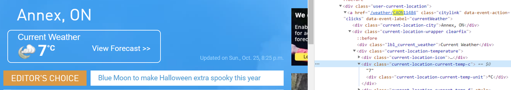

But many sites are actually pulling their data from some API that we can make use of. The inspect tab provides you with many tools for interacting with HTML documents. You can view the raw html code, and more importantly for our purposes, you can see the network trafic to the website.

Click on the Network tab and then refresh the page and see what is loaded.

[figure not shown]

We see above a whole bunch of resources that have been loaded. For each resource you can click on the header and preview tabs (highlighted above within the network tab) to see what data is sent to the website. We are interested in resources that return data, usually in a json format.

Exploring the first couple of resources above, we can see they are giving current weather, which is not quite what we want. If we click on the link for the first city we are presenting with when visiting the site, we will see something much more promising:

[figure not shown]

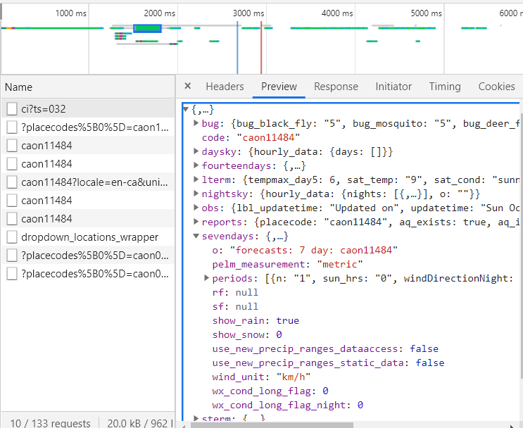

We see the link titled, `https://www.theweathernetwork.com/api/data/caon11484/cm/ci?ts=032` gives us exactly what we want! A json object with all of the data. Let’s extract that data in R

```r
library(dplyr)
library(jsonlite)
library(rvest)
library(ggplot2)

url <- "https://www.theweathernetwork.com/api/data/caon11484/cm/ci?ts=032"

df <- jsonlite::fromJSON(url)

# what objects are in here

names(df)
```

```
##  [1] "obs"          "sterm"        "lterm"        "sevendays"    "fourteendays"
##  [6] "reports"      "swo"          "bug"          "nightsky"     "daysky"
## [11] "type"         "code"
```

```r
# let's look at the seven day forecast

forecast7 <- df$sevendays

# also a lit
class(forecast7)
```

```
## [1] "list"
```

```r
# what is in it
names(forecast7)
```

```
##  [1] "periods"                           "show_rain"
##  [3] "show_snow"                         "wind_unit"
##  [5] "pelm_measurement"                  "wx_cond_long_flag"
##  [7] "wx_cond_long_flag_night"           "use_new_precip_ranges_dataaccess"
##  [9] "use_new_precip_ranges_static_data" "rf"
## [11] "sf"                                "o"
```

```r
forecast7p <- forecast7$periods

DT::datatable(head(forecast7p), options = list(scrollX = T))
```

|  | n | sun_hrs | windDirectionNight | windSpeedNight_kmh | gust_kmh | gustNight_kmh | feelsLikeNight_c | feelsLikeNight_unit | dewpt_unit | windSpeedNight | windSpeedNight_unit | gust_unit | gustNight_unit | feelsLikeNight | sun_hours | orig_rain | orig_snow | cdate | super_short_dayanddate | super_short_day | super_short_date | dotw | is_french | dayLong | rainDay | snowDay | rainNight | snowNight | imperial_temperatureMax | … |
| --- | --- | --- | --- | --- | --- | --- | --- | --- | --- | --- | --- | --- | --- | --- | --- | --- | --- | --- | --- | --- | --- | --- | --- | --- | --- | --- | --- | --- | --- | --- |
| 1 | 1 | 9 | W | 24 | 41 | 36 | 1 | C | C | 24 | km/h | km/h | km/h | 1 | 9 | 0.0 | 0.0 | Wednesday, October 28 | Wed 10/28 | Wed | 10/28 | 3 | False | Wednesday | - | - | - | - | 50 | … |
| 2 | 2 | 0 | NE | 24 | 30 | 36 | -4 | C | C | 24 | km/h | km/h | km/h | -4 | 0 | 1.1 | 0.0 | Thursday, October 29 | Thu 10/29 | Thu | 10/29 | 4 | False | Thursday | - | - | - | - | 46 | … |
| 3 | 3 | 9 | NW | 15 | 33 | 23 | -7 | C | C | 15 | km/h | km/h | km/h | -7 | 9 | 0.0 | 0.0 | Friday, October 30 | Fri 10/30 | Fri | 10/30 | 5 | False | Friday | - | - | - | - | 41 | … |
| 4 | 4 | 8 | S | 23 | 29 | 35 | 1 | C | C | 23 | km/h | km/h | km/h | 1 | 8 | 0.0 | 0.0 | Saturday, October 31 | Sat 10/31 | Sat | 10/31 | 6 | False | Saturday | - | - | - | - | 43 | … |
| 5 | 5 | 3 | W | 34 | 48 | 51 | -3 | C | C | 34 | km/h | km/h | km/h | -3 | 3 | 0.5 | 0.0 | Sunday, November 1 | Sun 11/01 | Sun | 11/01 | 0 | False | Sunday | - | - | - | - | 46 | … |
| 6 | 6 | 3 | W | 25 | 38 | 38 | -3 | C | C | 25 | km/h | km/h | km/h | -3 | 3 | 0.0 | 0.0 | Monday, November 2 | Mon 11/02 | Mon | 11/02 | 1 | False | Monday | - | - | - | - | 41 | … |

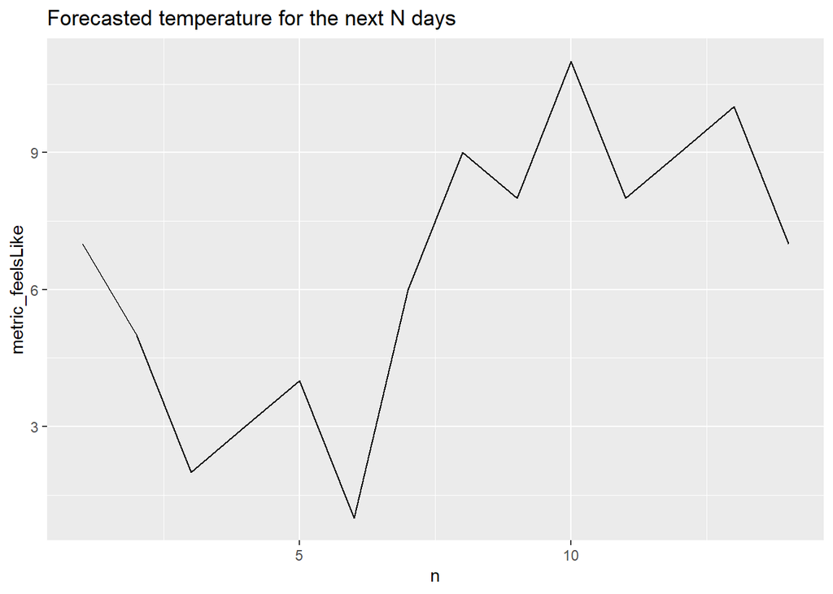

```r
forecast7p %>%
  mutate(n = as.numeric(n),
         metric_feelsLike = as.numeric(metric_feelsLike)) %>%
  ggplot(aes(n, metric_feelsLike)) +
  geom_line() +
  ggtitle("Forecasted temperature for the next N days")
```

This is fantastic because now we can access all of this data every day. The problem is that this is fairly limited because We would manually research what the link is each time we want to forecast data for a different city. Let’s see if we can automate this.

Looking back at the image of when we first loaded the website, we see a resource loaded called `-77.46434`. This looks weird, but also looks like maybe a latitude, or longitude. If we explore what is contained in the header, we get the following link

```r
url <- 'https://www.theweathernetwork.com/ca/api/maps/regional/9/45.06821/-81.34300/42.27356/-77.46434'

df <- jsonlite::fromJSON(url)

str(df)
```

```
## 'data.frame':    83 obs. of  32 variables:
##  $ id            : chr  "usny1490" "usny1490" "usny1895" "usny0400" ...
##  $ X             : num  -77.7 -77.7 -78.5 -79.3 -78.7 ...
##  $ Y             : num  42.3 42.3 42.3 42.5 42.5 ...
##  $ name_en       : chr  "Hornell" "Hornell" "Franklinville" "Dunkirk" ...
##  $ name_fr       : chr  "Hornell" "Hornell" "Franklinville" "Dunkirk" ...
##  $ name_de       : chr  "Hornell" "Hornell" "Franklinville" "Dunkirk" ...
##  $ country_en    : chr  "United States" "United States" "United States" "United States" ...
##  $ country_fr    : chr  "États-Unis" "États-Unis" "États-Unis" "États-Unis" ...
##  $ temp_c        : int  5 5 2 8 5 8 7 5 5 5 ...
##  $ temp_f        : int  41 41 35 46 41 46 44 41 41 41 ...
##  $ feelslike_c   : int  5 5 2 7 5 7 7 4 3 3 ...
##  $ feelslike_f   : int  41 41 35 44 41 44 44 39 37 37 ...
##  $ humidex       : int  5 5 2 8 5 8 7 5 5 5 ...
##  $ humidity      : chr  "" "" "" "" ...
##  $ timestamp     : int  1603792200 1603792200 1603792200 1603792200 1603792200 1603792200 1603792200 1603792200 1603792200 1603792200 ...
##  $ wind_kmh      : chr  "" "" "" "" ...
##  $ wind_mh       : int  4 4 0 7 2 7 0 7 8 7 ...
##  $ wind_direction: chr  "" "" "" "" ...
##  $ icon          : chr  "8" "8" "8" "8" ...
##  $ desc_en       : chr  "Overcast" "Overcast" "Overcast" "Overcast" ...
##  $ desc_fr       : chr  "Nuageux" "Nuageux" "Nuageux" "Nuageux" ...
##  $ name          : chr  "Hornell" "Hornell" "Franklinville" "Dunkirk" ...
##  $ country       : chr  "United States" "United States" "United States" "United States" ...
##  $ desc          : chr  "Overcast" "Overcast" "Overcast" "Overcast" ...
##  $ temp          : int  5 5 2 8 5 8 7 5 5 5 ...
##  $ unit          : chr  "C" "C" "C" "C" ...
##  $ feelslike     : int  5 5 2 7 5 7 7 4 3 3 ...
##  $ wind          : chr  "" "" "" "" ...
##  $ feelslike_set : logi  TRUE TRUE TRUE TRUE TRUE TRUE ...
##  $ pos           : int  NA NA NA NA NA NA NA NA NA NA ...
##  $ distance      : num  NA NA NA NA NA NA NA NA NA NA ...
##  $ coord         :'data.frame':  83 obs. of  30 variables:
##   ..$ id            : chr  NA NA NA NA ...
##   ..$ X             : num  NA NA NA NA NA NA NA NA NA NA ...
##   ..$ Y             : num  NA NA NA NA NA NA NA NA NA NA ...
##   ..$ name_en       : chr  NA NA NA NA ...
##   ..$ name_fr       : chr  NA NA NA NA ...
##   ..$ name_de       : chr  NA NA NA NA ...
##   ..$ country_en    : chr  NA NA NA NA ...
```

[output cut: 8 more lines]

```
##   ..$ wind_kmh      : chr  NA NA NA NA ...
##   ..$ wind_mh       : int  NA NA NA NA NA NA NA NA NA NA ...
##   ..$ wind_direction: chr  NA NA NA NA ...
##   ..$ icon          : chr  NA NA NA NA ...
##   ..$ desc_en       : chr  NA NA NA NA ...
##   ..$ desc_fr       : chr  NA NA NA NA ...
##   ..$ name          : chr  NA NA NA NA ...
##   ..$ country       : chr  NA NA NA NA ...
##   ..$ desc          : chr  NA NA NA NA ...
##   ..$ temp          : int  NA NA NA NA NA NA NA NA NA NA ...
##   ..$ unit          : chr  NA NA NA NA ...
##   ..$ feelslike     : int  NA NA NA NA NA NA NA NA NA NA ...
##   ..$ wind          : chr  NA NA NA NA ...
##   ..$ feelslike_set : logi  NA NA NA NA NA NA ...
##   ..$ placecode     : chr  NA NA NA NA ...
```

```r
df$id
```

```
##  [1] "usny1490"  "usny1490"  "usny1895"  "usny0400"  "usny1191"  "usny1588"
##  [7] "usny1725"  "caon0564"  "caon0550"  "caon0565"  "caon3308"  "usny1186"
## [13] "caon0554"  "usny1391"  "caon0615"  "usny0712"  "caon0776"  "caon0552"
## [19] "usny0181"  "caon0383"  "caon0286"  "usny1394"  "caon0736"  "usny1176"
## [25] "caon0475"  "caon0765"  "caon0081"  "caon0638"  "usny0486"  "usny1232"
## [31] "caon0289"  "usny2109"  "usny1162"  "usny1537"  "caon0658"  "caon0109"
## [37] "caon0356"  "caon0493"  "caon0434"  "caon0216"  "caon0441"  "caon0696"
## [43] "caon0080"  "caon0379"  "caon0226"  "caon7173"  "caon0538"  "caon0585"
## [49] "caon0505"  "caon0511"  "caon0151"  "caon0454"  "caon0473"  "caon0621"
## [55] "caon0706"  "caon0698"  "caon0078"  "caon0292"  "caon0342"  "caon4971"
## [61] "caon0320"  "caon0536"  "caon0171"  "caon4235"  "caon0376"  "caon0040"
## [67] "caon0649"  "caon0134"  "caon0395"  "caon0353"  "caon0515"  "caon0425"
## [73] "caon0506"  "caon0602"  "caon4723"  "caon0430"  "caon0018"  "caon0280"
## [79] "caon7147"  "caon0438"  "caon11350" "caon0039"  NA
```

```r
df$name_en
```

```
##  [1] "Hornell"           "Hornell"           "Franklinville"
##  [4] "Dunkirk"           "Springville"       "Silver Creek"
##  [7] "Wayland"           "Port Rowan"        "Port Burwell"
## [10] "Port Stanley"      "Turkey Point"      "Warsaw"
## [13] "Port Dover"        "Geneseo"           "Selkirk"
## [16] "West Seneca"       "Crystal Beach"     "Port Colborne"
## [19] "Buffalo"           "London"            "Haldimand"
## [22] "Le Roy"            "Welland"           "Batavia"
## [25] "Niagara Falls"     "Woodstock"         "Brantford"
## [28] "St. Catharines"    "Irondequoit"       "Rochester"
## [31] "Hamilton"          "Youngstown"        "Albion"
## [34] "Newfane"           "Stratford"         "Cambridge"
## [37] "Kitchener"         "Oakville"          "Milton"
## [40] "Elmira"            "Mississauga"       "Toronto"
## [43] "Brampton"          "Listowel"          "Erin"
## [46] "Duffins Bay"       "Pickering"         "Richmond Hill"
## [49] "Orangeville"       "Oshawa"            "Cobourg"
## [52] "Mount Forest"      "Newmarket"         "Shelburne"
## [55] "Uxbridge"          "Trenton"           "Bradford"
## [58] "Hanover"           "Keswick"           "Trent Hills"
## [61] "Innisfil"          "Peterborough"      "Creemore"
## [64] "Singhampton"       "Lindsay"           "Barrie"
## [67] "Stayner"           "Chatsworth"        "Madoc"
## [70] "Kirkfield"         "Owen Sound"        "Meaford"
## [73] "Orillia"           "Sauble Beach"      "Blue Mountain"
## [76] "Midland"           "Apsley"            "Gravenhurst"
## [79] "Neyaashiinigmiing" "Minden"            "Gillies Lake"
## [82] "Bancroft"          NA
```

and bingo! We get the ids of all the different cities. We can also see from the query that it looks like we are submitting some kind of bounding box in terms of latitude, longitude.

Let’s write a function that grabs the station ids for a given longitude/latiude.

```r
get_station_ids <- function(lat1, lat2, lon1, lon2) {
  url <- glue::glue('https://www.theweathernetwork.com/ca/api/maps/regional/9/{lat1}/{lon1}/{lat2}/{lon2}')
  df <- jsonlite::fromJSON(url)

  station_ids <- df %>%
    select(name = name_en, id)

  return(station_ids)
}
```

Let’s try this function with my home province (New Brunswick).

Here are the bounding boxes (lat and lon) of the Canadian provinces

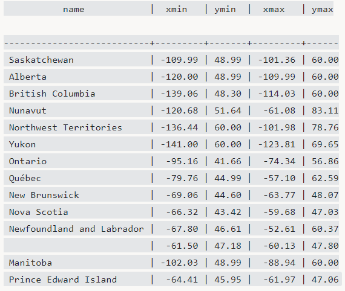

```r
nb_station_ids <- get_station_ids(lon1 = "-69.06",
                                  lon2 = "-63.77",
                                  lat1 = "44.60",
                                  lat2 = "48.07")
```

Now we can write a generalized function to get forecasts for a city we want to know more about

```r
get_city_7d_forecast <- function(station_id) {

  url <- glue::glue("https://www.theweathernetwork.com/api/data/{station_id}/cm/ci?ts=032")

  df <- jsonlite::fromJSON(url)

  forecast7 <- df$sevendays$periods

  return(forecast7)

}
```

```r
all_forecasts <- list()

nb_station_ids <- nb_station_ids %>%
  slice(1:15)
for(i in 1:nrow(nb_station_ids)) {

  tmp <- get_city_7d_forecast(nb_station_ids$id[i])
  tmp <- tmp %>%
    mutate(city = nb_station_ids$name[i],
           city_id = nb_station_ids$id[i]) %>%
    select(city, city_id, everything())

  all_forecasts[[nb_station_ids$name[i]]] <- tmp

  # sleep for a couple of seconds to be kind/mindful of their servers

  cat("Downloaded data for city", nb_station_ids$name[[i]], "\n")
  Sys.sleep(2)

}
```

```
## Downloaded data for city Digby
## Downloaded data for city Digby
## Downloaded data for city Cutler
## Downloaded data for city Dalhousie Crossing
## Downloaded data for city Machias
## Downloaded data for city West Dalhousie
## Downloaded data for city New Ross
## Downloaded data for city Carmel
## Downloaded data for city Bangor
## Downloaded data for city Lubec
## Downloaded data for city Levant
## Downloaded data for city Eastport
## Downloaded data for city Orono
## Downloaded data for city Wesley
## Downloaded data for city Port Lorne
```

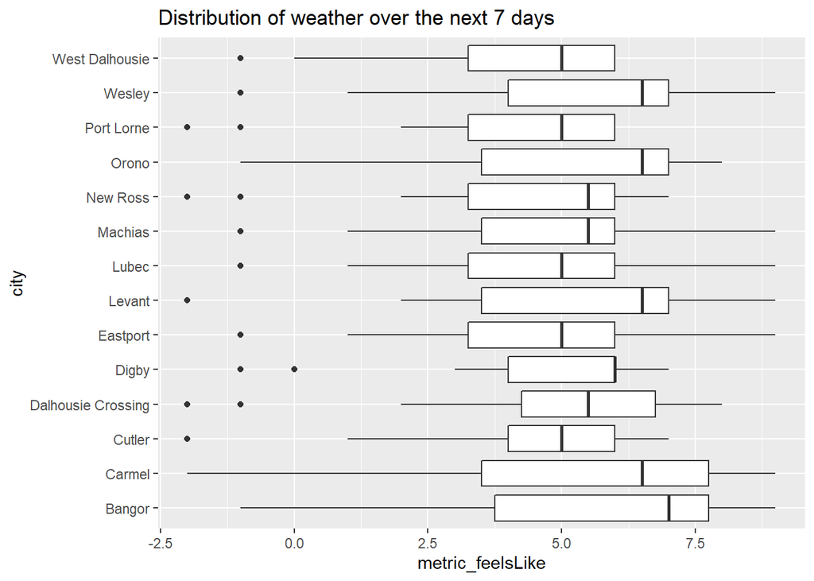

```r
all_forecasts_df <- do.call(rbind, all_forecasts)


all_forecasts_df %>%
  mutate(metric_feelsLike = as.numeric(metric_feelsLike)) %>%
  ggplot(aes(city, metric_feelsLike)) +
  geom_boxplot() +
  coord_flip() +
  ggtitle("Distribution of weather over the next 7 days")
```

## Summary

It takes some playing around/exploring to find what you are looking for. The best way to learn this stuff is through trial and error. I suggest picking a website you like and trying to extract some data from it (as long as it isn’t forbidden by the site).